# Entregable 1 - Data cleaning

### Outliers dias_venta

```
límites iqr:  LI:  1404.5 LS:  2128.5
Axes(0.125,0.11;0.775x0.77) Text(0.5, 1.0, 'Distribución outliers: dias_venta')
count    1089.0000
mean     2246.6309
std      1297.4632
min       215.0000
25%      1280.0000
50%      2161.0000
75%      2677.0000
max     10258.0000
dtype: float64
```

```
846     215.0000
39      273.0000
779     424.0000
375     426.0000
887     455.0000
         ...
493    7701.0000
698    7821.0000
10     8248.0000
624    8856.0000
551   10258.0000
Length: 1089, dtype: float64
```

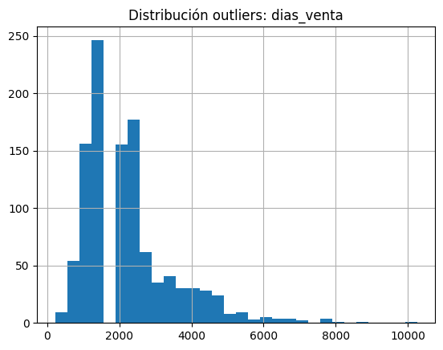

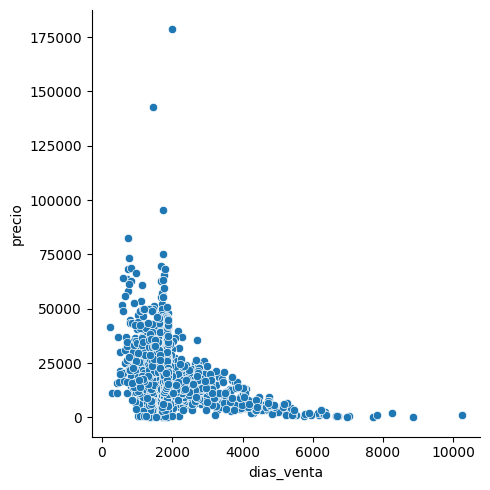

```python
## determino los quartiles de la variable, y la iqr

q1 = np.percentile(bmw2['dias_venta'], 25)          # Actualizar con el nombre de la variable
q3 = np.percentile(bmw2['dias_venta'], 75)
iqr = q3 - q1

limite_inferior = q1 - 1.5 * iqr
limite_superior = q3 + 1.5 * iqr


outliers_dias_venta = [x for x in bmw2['dias_venta'] if (limite_inferior > x) | (x > limite_superior)]  # Actualizar con el nombre de la variable

#  filtro la columna 'i' del DataFrame bmw4 y selecciono solamente aquellos valores que se encuentren dentro del rango definido por el
# límite inferior y el límite superior.

outliers_dias_venta = pd.Series(outliers_dias_venta).sort_values(ascending=True)        # Actualizar con el nombre de la variable

print('límites iqr: ', 'LI: ', limite_inferior, 'LS: ',  limite_superior)

print(
    outliers_dias_venta.hist(bins=30),                              # Actualizar con el nombre de la variable
    plt.title(f"Distribución outliers: dias_venta"))

sns.relplot(data=bmw2, x=bmw2['dias_venta'], y=bmw2["precio"]);             # Actualizar con el nombre de la variable

print(outliers_dias_venta.describe())
outliers_dias_venta
```

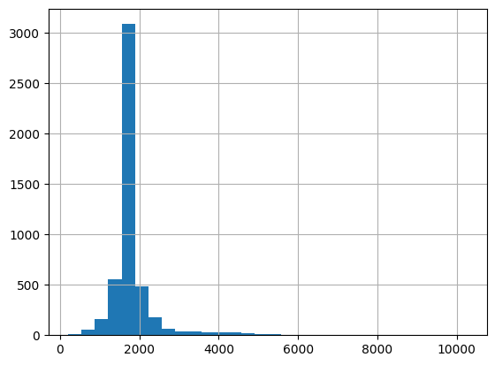

```python
bmw2['dias_venta'].hist(bins=30)
```

```python
bmw2['dias_venta'].std()
```

```
659.4929896275469
```

```python
bmw2['dias_venta'].mean() - 3*(bmw2['dias_venta'].std()), bmw2['dias_venta'].mean() + 3*(bmw2['dias_venta'].std())
```

```
(-111.63370737749256, 3845.3242303877887)
```

Los outliers en dias_venta son todos valores positivos. Al mismo tiempo, la alta presencia de outliers (1089) se debe a la baja variabilidad de la variable std = 659.4930, lo que deja muchos valores a la derecha del upper_bound.

No modificamos la variable para conservar la información original.

Por otro lado, la concentración (poca variabilidad) en los valores de la variable se deben a la imputación de nulos que se hizo previamente: Una de las variables que da origen a dias_venta es fecha_registro, que presenta 2423 nulos (50% de la muestra) y que fueron imputados a la mediana de fecha_registro.

### Análisis de baja varianza

```python
## Eliminamos las variables de baja varianza

from sklearn.feature_selection import VarianceThreshold
```

```python
## Genero un dataset con los valores de las varianzas menores al umbral definido

bmw2_var = ((bmw2[l_num].var()).to_frame(name='variance'))
umbral_var = 0.01

bmw2_low_var = bmw2_var.loc[bmw2_var['variance'] < umbral_var]

bmw2_low_var
```

|  | variance |
| --- | --- |

```python
bmw2[l_num].var()
```

```
km                     3627717431.3483
potencia                     1521.0813
volante_regulable               0.2475
aire_acondicionado              0.1502
camara_trasera                  0.1610
elevalunas_electrico            0.2485
bluetooth                       0.1634
gps                             0.0629
alerta_lim_velocidad            0.2480
dias_venta                 434931.0034
dtype: float64
```

```python
## Calcula la varianza y lista las variables que están fuera del umbral. La línea comentada borra las variables de baja var. determinada

vt = VarianceThreshold(threshold = 0.01)     # Eliminamos columnas donde el 99% de losvalores son iguales

vt.fit(bmw2[l_num])
cols_lowvar = bmw2[l_num].columns[vt.get_support()==False]
print(len(cols_lowvar),' low variance features will be removed:\n', cols_lowvar.to_list())

# bmw2[l_num].drop(columns=cols_lowvar,inplace=True)
bmw2.shape
```

```
0  low variance features will be removed:
 []
```

```
(4818, 16)
```

Después de analizar la varianza de las variables luego de la primera correlación, vemos que no hay variables que tengan que ser eliminadas por estar fuera del umbral determinado: VarianceThreshold = 0.01.

### Segundo checkpoint, con los nulos y outliers terminados

```python
## Hago el segundo checkpoint, habiendo terminado con los nulos y outliers

bmw3 = bmw2.copy()
```

## Determinar el target y analizarlo

```
    ### Crear listas de tipos de variables
```

```python
target = ['log_precio', 'precio']

def obtener_lista_variables(dataset):       # Función crea lista de variables según su tipo
    lista_numericas = []
    lista_categ = []

    for i in dataset:
        if (dataset[i].dtype.kind == 'f' or dataset[i].dtype.kind == 'i') and i not in target:
            lista_numericas.append(i)
            print(dataset.hist(i))
            print(dataset[i].describe())
            print('-----------------------------------------------------------')

        elif (dataset[i].dtype.kind == 'O') and i not in target:
            lista_categ.append(i)
            print(dataset[i].value_counts())
            dataset[i].value_counts()/len(dataset) * 100
            print('-----------------------------------------------------------')
    lista_numericas.insert(0, target[0])


    return lista_numericas, lista_categ
```

```
[[<Axes: title={'center': 'km'}>]]
count      4818.0000
mean     140991.1729
std       60230.5357
min         476.0000
25%      102863.0000
50%      141027.0000
75%      175247.7500
max     1000376.0000
Name: km, dtype: float64
-----------------------------------------------------------
[[<Axes: title={'center': 'potencia'}>]]
count   4818.0000
mean     128.9830
std       39.0010
min        0.0000
25%      100.0000
50%      120.0000
75%      135.0000
max      423.0000
Name: potencia, dtype: float64
-----------------------------------------------------------
tipo_gasolina
diesel           4611
petrol            191
hybrid_petrol       8
Diesel              5
electro             3
Name: count, dtype: int64
-----------------------------------------------------------
[[<Axes: title={'center': 'volante_regulable'}>]]
count   4818.0000
mean       0.5504
std        0.4975
min        0.0000
25%        0.0000
50%        1.0000
75%        1.0000
max        1.0000
Name: volante_regulable, dtype: Float64
```

[output cut: 90 more lines]

```
grey     1067
blue      643
white     480
Name: count, dtype: int64
-----------------------------------------------------------
modelo_gouped
Otros    1810
320       747
520       630
318       562
X3        437
116       358
X1        274
Name: count, dtype: int64
-----------------------------------------------------------
```

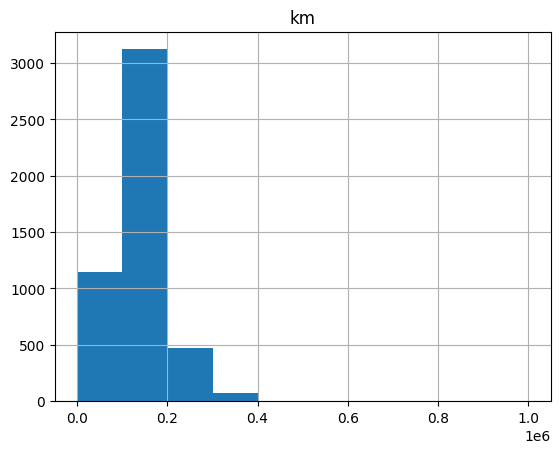

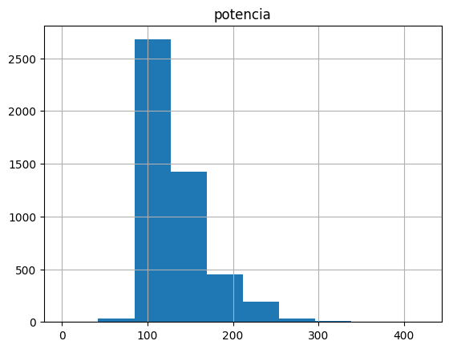

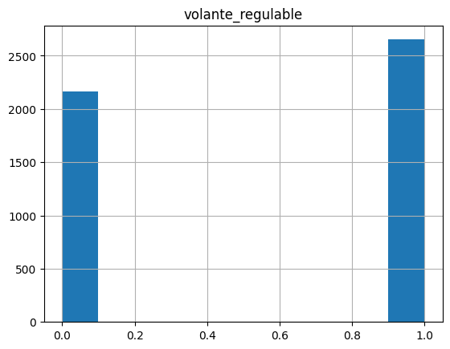

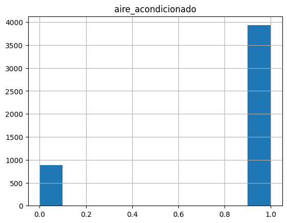

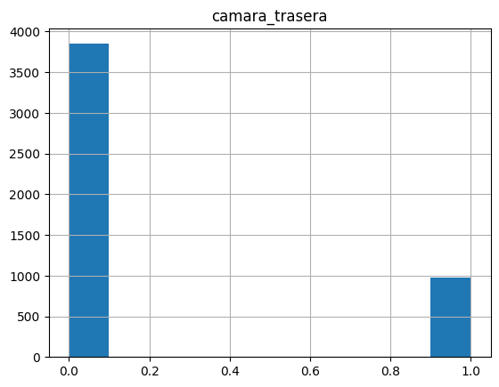

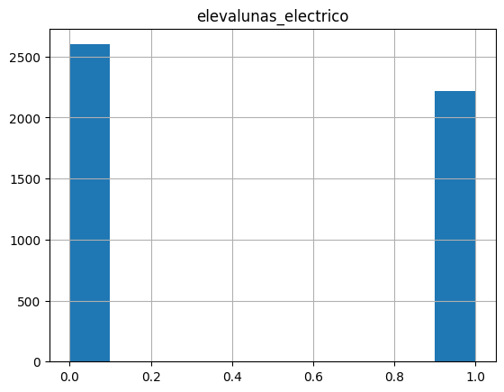

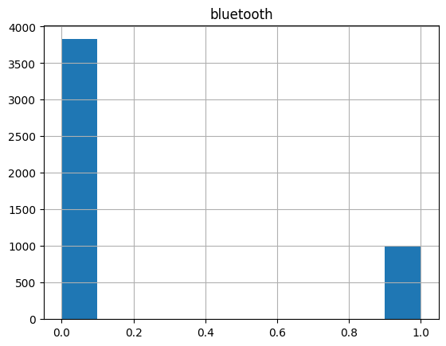

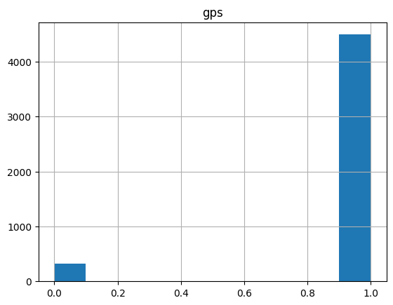

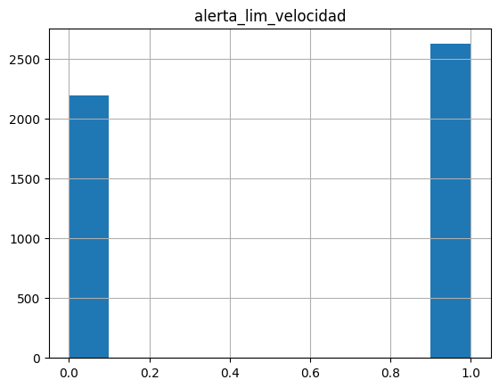

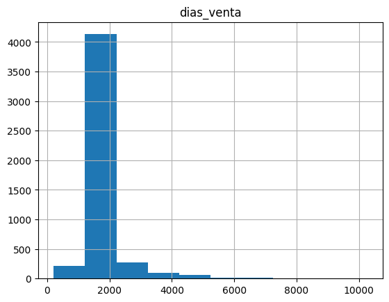

```python
l_num, l_categ = obtener_lista_variables(bmw3)
```

```python
l_num
```

```
['log_precio',
 'km',
 'potencia',
 'volante_regulable',
 'aire_acondicionado',
 'camara_trasera',
 'elevalunas_electrico',
 'bluetooth',
 'gps',
 'alerta_lim_velocidad',
 'dias_venta']
```

```python
bmw3.head()
```

|  | precio | km | potencia | tipo_gasolina | volante_regulable | aire_acondicionado | camara_trasera | elevalunas_electrico | bluetooth | gps | alerta_lim_velocidad | dias_venta | tipo_coche_grouped | color_grouped | modelo_gouped | log_precio |
| --- | --- | --- | --- | --- | --- | --- | --- | --- | --- | --- | --- | --- | --- | --- | --- | --- |
| 0 | 11300.0000 | 140411.0000 | 100.0000 | diesel | 1 | 1 | 0 | 1 | 0 | 1 | 0 | 2161.0000 | Sin datos | black | Otros | 4.0531 |
| 1 | 69700.0000 | 13929.0000 | 317.0000 | petrol | 1 | 1 | 0 | 0 | 1 | 1 | 1 | 1676.0000 | Otros | grey | Otros | 4.8432 |
| 2 | 10200.0000 | 183297.0000 | 120.0000 | diesel | 0 | 0 | 0 | 1 | 0 | 1 | 0 | 2132.0000 | Sin datos | white | 320 | 4.0086 |
| 3 | 25100.0000 | 128035.0000 | 135.0000 | diesel | 1 | 1 | 0 | 1 | 1 | 1 | 0 | 1676.0000 | Otros | Otros | Otros | 4.3997 |
| 4 | 33400.0000 | 97097.0000 | 160.0000 | diesel | 1 | 1 | 0 | 0 | 1 | 1 | 1 | 1735.0000 | Sin datos | Otros | Otros | 4.5237 |

```python
bmw3.shape
```

```
(4818, 16)
```

```python
'variables categóricas:', len(l_categ), l_categ, '\n' , 'variables numéricas: ', len(l_num), l_num
```

```
('variables categóricas:',
 4,
 ['tipo_gasolina', 'tipo_coche_grouped', 'color_grouped', 'modelo_gouped'],
 '\n',
 'variables numéricas: ',
 11,
 ['log_precio',
  'km',
  'potencia',
  'volante_regulable',
  'aire_acondicionado',
  'camara_trasera',
  'elevalunas_electrico',
  'bluetooth',
  'gps',
  'alerta_lim_velocidad',
  'dias_venta'])
```

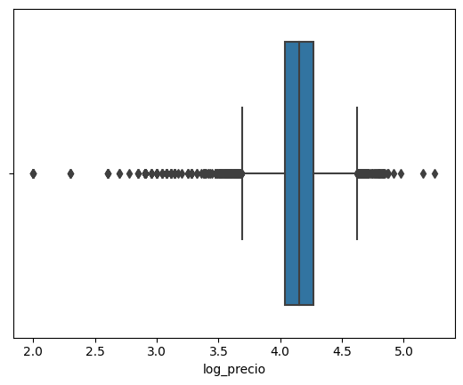

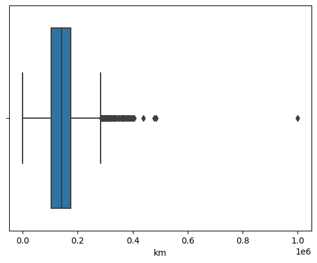

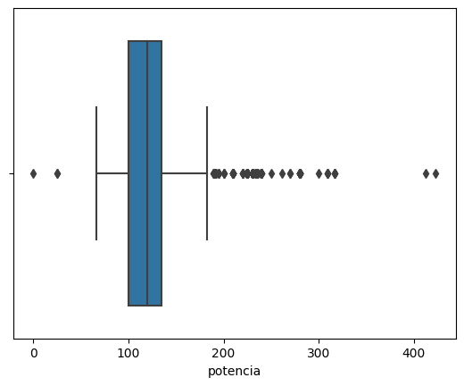

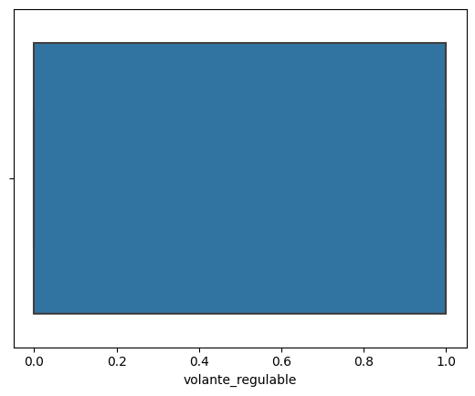

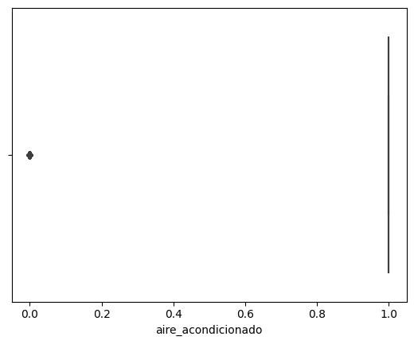

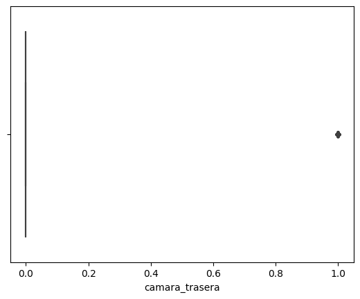

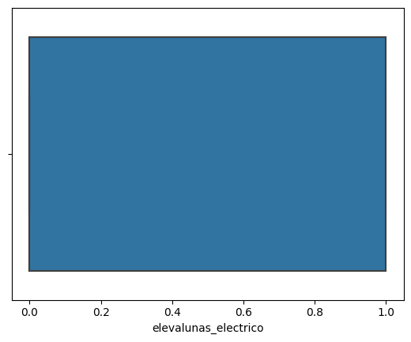

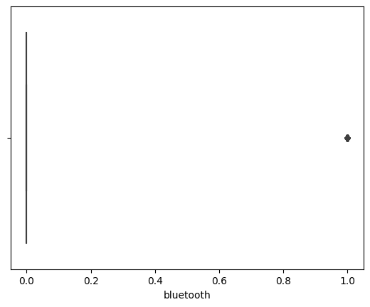

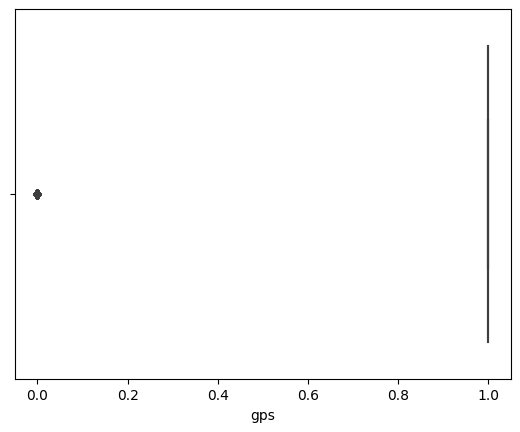

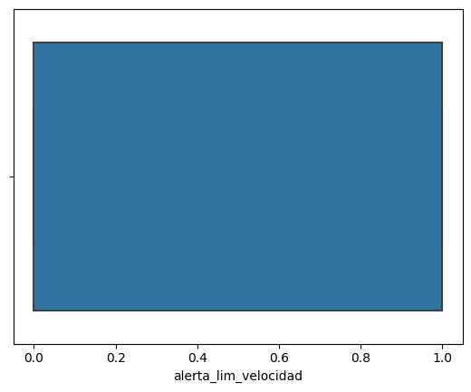

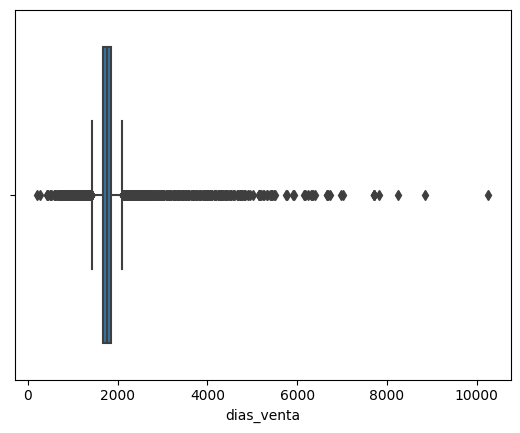

```python
for i in l_num:
    sns.boxplot(x = i, data = bmw3)
    plt.show()
```

### Tiro la primera correlación

```python
#importamos librería
import pandas as pd
import numpy as np
import matplotlib.pyplot as plt
import seaborn as sns

from sklearn.preprocessing import LabelEncoder,MinMaxScaler

import folium
import plotly.express as px
```

```python
bmw3_num = bmw3[l_num]
corr = bmw3_num.corr()
corr.style.background_gradient(cmap='coolwarm')
```

|  | log_precio | km | potencia | volante_regulable | aire_acondicionado | camara_trasera | elevalunas_electrico | bluetooth | gps | alerta_lim_velocidad | dias_venta |
| --- | --- | --- | --- | --- | --- | --- | --- | --- | --- | --- | --- |
| log_precio | 1.000000 | -0.437024 | 0.507280 | 0.249229 | 0.306431 | 0.197502 | 0.318337 | 0.181789 | 0.043278 | 0.354288 | -0.423337 |
| km | -0.437024 | 1.000000 | -0.048634 | 0.066609 | 0.013230 | 0.002373 | 0.046133 | -0.031705 | 0.155410 | -0.037242 | 0.334468 |
| potencia | 0.507280 | -0.048634 | 1.000000 | 0.327227 | 0.182012 | 0.312569 | 0.342225 | 0.203449 | 0.008286 | 0.420227 | -0.064748 |
| volante_regulable | 0.249229 | 0.066609 | 0.327227 | 1.000000 | 0.286619 | 0.253295 | 0.277563 | 0.124405 | 0.242701 | 0.183578 | 0.047787 |
| aire_acondicionado | 0.306431 | 0.013230 | 0.182012 | 0.286619 | 1.000000 | 0.142528 | 0.258419 | 0.102607 | 0.341993 | 0.176651 | -0.137169 |
| camara_trasera | 0.197502 | 0.002373 | 0.312569 | 0.253295 | 0.142528 | 1.000000 | 0.198050 | 0.125802 | 0.060855 | 0.172440 | 0.017697 |
| elevalunas_electrico | 0.318337 | 0.046133 | 0.342225 | 0.277563 | 0.258419 | 0.198050 | 1.000000 | 0.232392 | 0.202026 | 0.296860 | -0.067316 |
| bluetooth | 0.181789 | -0.031705 | 0.203449 | 0.124405 | 0.102607 | 0.125802 | 0.232392 | 1.000000 | 0.114341 | 0.079471 | -0.048091 |
| gps | 0.043278 | 0.155410 | 0.008286 | 0.242701 | 0.341993 | 0.060855 | 0.202026 | 0.114341 | 1.000000 | -0.054722 | 0.062434 |
| alerta_lim_velocidad | 0.354288 | -0.037242 | 0.420227 | 0.183578 | 0.176651 | 0.172440 | 0.296860 | 0.079471 | -0.054722 | 1.000000 | -0.089770 |
| dias_venta | -0.423337 | 0.334468 | -0.064748 | 0.047787 | -0.137169 | 0.017697 | -0.067316 | -0.048091 | 0.062434 | -0.089770 | 1.000000 |

```python
resultado_corr = bmw3_num.corr().unstack().sort_values(ascending = False)

corr2_frame = resultado_corr.to_frame().reset_index()
corr2_frame.columns = ['var_1', 'var_2', 'corr']

umbral_corr = 0.4000

corr2_matrix = corr2_frame[((corr2_frame['corr'] > umbral_corr) | (corr2_frame['corr'] < -umbral_corr)) & (corr2_frame['var_1'] != corr2_frame['var_2'])]

corr2_matrix
```

|  | var_1 | var_2 | corr |
| --- | --- | --- | --- |
| 11 | log_precio | potencia | 0.5073 |
| 12 | potencia | log_precio | 0.5073 |
| 13 | alerta_lim_velocidad | potencia | 0.4202 |
| 14 | potencia | alerta_lim_velocidad | 0.4202 |
| 117 | dias_venta | log_precio | -0.4233 |
| 118 | log_precio | dias_venta | -0.4233 |
| 119 | log_precio | km | -0.4370 |
| 120 | km | log_precio | -0.4370 |

Al hacer la correlación con log_precio, en lugar de precio, vemos que log_precio presenta (aunque baja) correlación con 3 variables -potencia, dias_venta y km - a diferencia de cuando analizamos la correlación con precio como target. Por lo que decidimos eliminar precio y seguir trabajando con log_precio

```python
del bmw3['precio']
```

```python
bmw3['log_precio']
```

```
0      4.0531
1      4.8432
2      4.0086
3      4.3997
4      4.5237
        ...
4838   4.1644
4839   4.2430
4840   4.2304
4841   4.3560
4842   4.1903
Name: log_precio, Length: 4818, dtype: float64
```

```python
# Aquí extraigo la columna log_precio, luego la elimino del dataframe, y por
# último la ubico al principio del DataFrame para poder calcular la correlación
# entre el precio y las restantes columnas

log_precio = bmw3['log_precio']
bmw3 = bmw3.drop('log_precio', axis=1)
bmw3.insert(0, 'log_precio', log_precio)
```

```python
print(bmw3.shape)
bmw3.head()
```

```
(4818, 15)
```

|  | log_precio | km | potencia | tipo_gasolina | volante_regulable | aire_acondicionado | camara_trasera | elevalunas_electrico | bluetooth | gps | alerta_lim_velocidad | dias_venta | tipo_coche_grouped | color_grouped | modelo_gouped |
| --- | --- | --- | --- | --- | --- | --- | --- | --- | --- | --- | --- | --- | --- | --- | --- |
| 0 | 4.0531 | 140411.0000 | 100.0000 | diesel | 1 | 1 | 0 | 1 | 0 | 1 | 0 | 2161.0000 | Sin datos | black | Otros |
| 1 | 4.8432 | 13929.0000 | 317.0000 | petrol | 1 | 1 | 0 | 0 | 1 | 1 | 1 | 1676.0000 | Otros | grey | Otros |
| 2 | 4.0086 | 183297.0000 | 120.0000 | diesel | 0 | 0 | 0 | 1 | 0 | 1 | 0 | 2132.0000 | Sin datos | white | 320 |
| 3 | 4.3997 | 128035.0000 | 135.0000 | diesel | 1 | 1 | 0 | 1 | 1 | 1 | 0 | 1676.0000 | Otros | Otros | Otros |
| 4 | 4.5237 | 97097.0000 | 160.0000 | diesel | 1 | 1 | 0 | 0 | 1 | 1 | 1 | 1735.0000 | Sin datos | Otros | Otros |

### Escalar las variables, con OneHot Encoding y MinMaxScaler

```python
""" Fórmula para borrar variables con variables muy correlacionadas, más allá del umbral definido

def remove_correlated_columns(df, threshold):
    col_corr = []
    corr_matrix = df.corr()
    for i in range(len(corr_matrix.columns)):
        for j in range(i):
            if (corr_matrix.iloc[i, j] >= threshold) and (corr_matrix.columns[j] not in col_corr):
                col_corr.append(corr_matrix.columns[i])
    df = df.drop(columns=col_corr)
    return df
remove_correlated_columns(df_bmw_cleaned_num, threshold=0.9)

"""
```

```
' Fórmula para borrar variables con variables muy correlacionadas, más allá del umbral definido\n\ndef remove_correlated_columns(df, threshold):\n    col_corr = []\n    corr_matrix = df.corr()\n    for i in range(len(corr_matrix.columns)):\n        for j in range(i):\n            if (corr_matrix.ilo…
```

```python
target = ['log_precio']

def actualizar_lista_variables(dataset):       # Función crea lista de variables según su tipo
    lista_numericas = []
    lista_categ = []

    for i in dataset:
        if (dataset[i].dtype.kind == 'f' or dataset[i].dtype.kind == 'i') and i not in target:
            lista_numericas.append(i)

        elif (dataset[i].dtype.kind == 'O') and i not in target:
            lista_categ.append(i)


    return lista_numericas, lista_categ
```

```python
l_num, l_cat = actualizar_lista_variables(bmw3)

l_num, l_cat
```

```
(['km',
  'potencia',
  'volante_regulable',
  'aire_acondicionado',
  'camara_trasera',
  'elevalunas_electrico',
  'bluetooth',
  'gps',
  'alerta_lim_velocidad',
  'dias_venta'],
 ['tipo_gasolina', 'tipo_coche_grouped', 'color_grouped', 'modelo_gouped'])
```

```python
minMaxResultado=MinMaxScaler()
```

```python
bmw3[l_num]=minMaxResultado.fit_transform(bmw3[l_num]) # Transformar columna a columna los valores que tiene entre 0 y 1
```

```python
bmw3.head()
```

|  | log_precio | km | potencia | tipo_gasolina | volante_regulable | aire_acondicionado | camara_trasera | elevalunas_electrico | bluetooth | gps | alerta_lim_velocidad | dias_venta | tipo_coche_grouped | color_grouped | modelo_gouped |
| --- | --- | --- | --- | --- | --- | --- | --- | --- | --- | --- | --- | --- | --- | --- | --- |
| 0 | 4.0531 | 0.1399 | 0.2364 | diesel | 1.0000 | 1.0000 | 0.0000 | 1.0000 | 0.0000 | 1.0000 | 0.0000 | 0.1938 | Sin datos | black | Otros |
| 1 | 4.8432 | 0.0135 | 0.7494 | petrol | 1.0000 | 1.0000 | 0.0000 | 0.0000 | 1.0000 | 1.0000 | 1.0000 | 0.1455 | Otros | grey | Otros |
| 2 | 4.0086 | 0.1828 | 0.2837 | diesel | 0.0000 | 0.0000 | 0.0000 | 1.0000 | 0.0000 | 1.0000 | 0.0000 | 0.1909 | Sin datos | white | 320 |
| 3 | 4.3997 | 0.1276 | 0.3191 | diesel | 1.0000 | 1.0000 | 0.0000 | 1.0000 | 1.0000 | 1.0000 | 0.0000 | 0.1455 | Otros | Otros | Otros |
| 4 | 4.5237 | 0.0966 | 0.3783 | diesel | 1.0000 | 1.0000 | 0.0000 | 0.0000 | 1.0000 | 1.0000 | 1.0000 | 0.1513 | Sin datos | Otros | Otros |

### Correr el One Hot Encoder

```python
bmw3 = pd.get_dummies(bmw3, columns=l_cat)
```

```python
bmw3.head()
```

|  | log_precio | km | potencia | volante_regulable | aire_acondicionado | camara_trasera | elevalunas_electrico | bluetooth | gps | alerta_lim_velocidad | ... | color_grouped_blue | color_grouped_grey | color_grouped_white | modelo_gouped_116 | modelo_gouped_318 | modelo_gouped_320 | modelo_gouped_520 | modelo_gouped_Otros | modelo_gouped_X1 | modelo_gouped_X3 |
| --- | --- | --- | --- | --- | --- | --- | --- | --- | --- | --- | --- | --- | --- | --- | --- | --- | --- | --- | --- | --- | --- |
| 0 | 4.0531 | 0.1399 | 0.2364 | 1.0000 | 1.0000 | 0.0000 | 1.0000 | 0.0000 | 1.0000 | 0.0000 | ... | False | False | False | False | False | False | False | True | False | False |
| 1 | 4.8432 | 0.0135 | 0.7494 | 1.0000 | 1.0000 | 0.0000 | 0.0000 | 1.0000 | 1.0000 | 1.0000 | ... | False | True | False | False | False | False | False | True | False | False |
| 2 | 4.0086 | 0.1828 | 0.2837 | 0.0000 | 0.0000 | 0.0000 | 1.0000 | 0.0000 | 1.0000 | 0.0000 | ... | False | False | True | False | False | True | False | False | False | False |
| 3 | 4.3997 | 0.1276 | 0.3191 | 1.0000 | 1.0000 | 0.0000 | 1.0000 | 1.0000 | 1.0000 | 0.0000 | ... | False | False | False | False | False | False | False | True | False | False |
| 4 | 4.5237 | 0.0966 | 0.3783 | 1.0000 | 1.0000 | 0.0000 | 0.0000 | 1.0000 | 1.0000 | 1.0000 | ... | False | False | False | False | False | False | False | True | False | False |

5 rows × 34 columns

```python
bmw3.shape
```

```
(4818, 34)
```

```python
bmw4 = bmw3.copy()
```

### Segunda correlación, con el dataset listo

```python
corr2 = bmw4.corr()
corr2.style.background_gradient(cmap='coolwarm')
```

|  | log_precio | km | potencia | volante_regulable | aire_acondicionado | camara_trasera | elevalunas_electrico | bluetooth | gps | alerta_lim_velocidad | dias_venta | tipo_gasolina_Diesel | tipo_gasolina_diesel | tipo_gasolina_electro | tipo_gasolina_hybrid_petrol | tipo_gasolina_petrol | tipo_coche_grouped_Otros | tipo_coche_grouped_Sin datos | tipo_coche_grouped_estate | tipo_coche_grouped_hatchback | tipo_coche_grouped_sedan | tipo_coche_grouped_suv | color_grouped_Otros | color_grouped_black | color_grouped_blue | color_grouped_grey | color_grouped_white | modelo_gouped_116 | modelo_gouped_318 | … |
| --- | --- | --- | --- | --- | --- | --- | --- | --- | --- | --- | --- | --- | --- | --- | --- | --- | --- | --- | --- | --- | --- | --- | --- | --- | --- | --- | --- | --- | --- | --- |
| log_precio | 1.000000 | -0.437024 | 0.507280 | 0.249229 | 0.306431 | 0.197502 | 0.318337 | 0.181789 | 0.043278 | 0.354288 | -0.423337 | -0.002295 | 0.086743 | 0.017124 | 0.053510 | -0.103123 | -0.016911 | -0.006457 | -0.134619 | -0.069999 | 0.018904 | 0.211551 | -0.041162 | 0.036492 | -0.048010 | -0.005337 | 0.064001 | -0.170598 | -0.172775 | … |
| km | -0.437024 | 1.000000 | -0.048634 | 0.066609 | 0.013230 | 0.002373 | 0.046133 | -0.031705 | 0.155410 | -0.037242 | 0.334468 | 0.005996 | 0.046264 | -0.037486 | -0.034932 | -0.036987 | -0.088598 | 0.003101 | 0.134160 | -0.096913 | 0.061431 | -0.092291 | 0.004816 | 0.034018 | -0.019939 | 0.023216 | -0.068866 | -0.108531 | 0.059263 | … |
| potencia | 0.507280 | -0.048634 | 1.000000 | 0.327227 | 0.182012 | 0.312569 | 0.342225 | 0.203449 | 0.008286 | 0.420227 | -0.064748 | 0.001998 | -0.118521 | -0.023885 | 0.025901 | 0.120491 | -0.026251 | -0.010900 | -0.042396 | -0.178994 | 0.029245 | 0.195751 | -0.035922 | 0.034223 | -0.011676 | 0.004040 | 0.005814 | -0.317756 | -0.258946 | … |
| volante_regulable | 0.249229 | 0.066609 | 0.327227 | 1.000000 | 0.286619 | 0.253295 | 0.277563 | 0.124405 | 0.242701 | 0.183578 | 0.047787 | -0.009747 | 0.008108 | 0.005832 | 0.016361 | -0.010977 | -0.033854 | -0.022862 | 0.003156 | -0.117013 | 0.057808 | 0.081503 | -0.014678 | 0.024741 | 0.011128 | 0.050930 | -0.100595 | -0.194179 | -0.096635 | … |
| aire_acondicionado | 0.306431 | 0.013230 | 0.182012 | 0.286619 | 1.000000 | 0.142528 | 0.258419 | 0.102607 | 0.341993 | 0.176651 | -0.137169 | 0.015310 | 0.078943 | 0.011857 | 0.006219 | -0.087380 | -0.099356 | -0.023413 | 0.080404 | -0.067732 | 0.058608 | -0.012068 | -0.036942 | 0.044185 | -0.000981 | 0.023777 | -0.047619 | -0.153333 | 0.009117 | … |
| camara_trasera | 0.197502 | 0.002373 | 0.312569 | 0.253295 | 0.142528 | 1.000000 | 0.198050 | 0.125802 | 0.060855 | 0.172440 | 0.017697 | -0.000123 | -0.010926 | -0.012540 | -0.007781 | 0.014602 | -0.027798 | 0.005384 | -0.035886 | -0.033183 | -0.013019 | 0.091201 | -0.039638 | 0.021176 | -0.000894 | 0.014904 | 0.003909 | -0.102882 | -0.098748 | … |
| elevalunas_electrico | 0.318337 | 0.046133 | 0.342225 | 0.277563 | 0.258419 | 0.198050 | 1.000000 | 0.232392 | 0.202026 | 0.296860 | -0.067316 | 0.021949 | -0.005469 | -0.023064 | -0.007001 | 0.006471 | -0.034415 | -0.006190 | 0.045441 | -0.071431 | 0.012046 | 0.021471 | -0.051535 | 0.078595 | -0.035685 | -0.016469 | 0.015195 | -0.171287 | -0.150267 | … |
| bluetooth | 0.181789 | -0.031705 | 0.203449 | 0.124405 | 0.102607 | 0.125802 | 0.232392 | 1.000000 | 0.114341 | 0.079471 | -0.048091 | 0.031443 | -0.031458 | -0.012702 | -0.008141 | 0.030827 | 0.038446 | -0.017068 | -0.015476 | 0.026593 | -0.009381 | 0.005529 | -0.042636 | 0.020815 | 0.007162 | -0.032732 | 0.065614 | -0.050193 | -0.042545 | … |
| gps | 0.043278 | 0.155410 | 0.008286 | 0.242701 | 0.341993 | 0.060855 | 0.202026 | 0.114341 | 1.000000 | -0.054722 | 0.062434 | 0.008669 | 0.045042 | 0.006713 | -0.009357 | -0.047145 | -0.003947 | -0.000342 | 0.057227 | -0.000224 | 0.038255 | -0.102812 | -0.004223 | 0.050933 | 0.005777 | 0.023866 | -0.112240 | 0.032024 | 0.033282 | … |
| alerta_lim_velocidad | 0.354288 | -0.037242 | 0.420227 | 0.183578 | 0.176651 | 0.172440 | 0.296860 | 0.079471 | -0.054722 | 1.000000 | -0.089770 | 0.003571 | -0.000452 | 0.006107 | 0.037276 | -0.008679 | -0.070390 | -0.003640 | -0.006640 | -0.111727 | 0.018505 | 0.125265 | -0.025077 | 0.046671 | -0.021236 | -0.015393 | 0.009019 | -0.241635 | -0.154765 | … |
| dias_venta | -0.423337 | 0.334468 | -0.064748 | 0.047787 | -0.137169 | 0.017697 | -0.067316 | -0.048091 | 0.062434 | -0.089770 | 1.000000 | -0.017197 | -0.144299 | -0.008435 | -0.011702 | 0.156319 | 0.005497 | -0.007579 | -0.019837 | -0.040982 | 0.073383 | -0.012520 | 0.012604 | 0.023417 | -0.003512 | 0.021305 | -0.079559 | -0.015964 | 0.020436 | … |
| tipo_gasolina_Diesel | -0.002295 | 0.005996 | 0.001998 | -0.009747 | 0.015310 | -0.000123 | 0.021949 | 0.031443 | 0.008669 | 0.003571 | -0.017197 | 1.000000 | -0.152121 | -0.000805 | -0.001314 | -0.006549 | -0.006846 | -0.007094 | 0.043989 | -0.010820 | -0.014608 | -0.013883 | -0.017934 | -0.007606 | 0.006307 | 0.029383 | -0.010721 | -0.009132 | 0.008370 | … |
| tipo_gasolina_diesel | 0.086743 | 0.046264 | -0.118521 | 0.008108 | 0.078943 | -0.010926 | -0.005469 | -0.031458 | 0.045042 | -0.000452 | -0.144299 | -0.152121 | 1.000000 | -0.117808 | -0.192480 | -0.958913 | -0.146369 | 0.018517 | 0.051580 | -0.023862 | -0.037369 | 0.057457 | 0.002255 | -0.002274 | 0.013923 | -0.012714 | 0.002128 | -0.014124 | 0.038729 | … |
| tipo_gasolina_electro | 0.017124 | -0.037486 | -0.023885 | 0.005832 | 0.011857 | -0.012540 | -0.023064 | -0.012702 | 0.006713 | 0.006107 | -0.008435 | -0.000805 | -0.117808 | 1.000000 | -0.001018 | -0.005071 | -0.005302 | 0.001762 | -0.013553 | 0.046775 | -0.011313 | -0.010752 | -0.013889 | -0.016694 | -0.009796 | 0.026763 | 0.019478 | -0.007072 | -0.009070 | … |
| tipo_gasolina_hybrid_petrol | 0.053510 | -0.034932 | 0.025901 | 0.016361 | 0.006219 | -0.007781 | -0.007001 | -0.008141 | -0.009357 | 0.037276 | -0.011702 | -0.001314 | -0.192480 | -0.001018 | 1.000000 | -0.008286 | 0.016420 | 0.006584 | -0.022143 | 0.003205 | -0.004925 | 0.010496 | -0.010693 | 0.016852 | -0.001014 | 0.002803 | -0.013566 | -0.011554 | -0.014820 | … |
| tipo_gasolina_petrol | -0.103123 | -0.036987 | 0.120491 | -0.010977 | -0.087380 | 0.014602 | 0.006471 | 0.030827 | -0.047145 | -0.008679 | 0.156319 | -0.006549 | -0.958913 | -0.005071 | -0.008286 | 1.000000 | 0.150494 | -0.019672 | -0.054509 | 0.019935 | 0.043720 | -0.058236 | 0.004623 | 0.002236 | -0.014046 | 0.004357 | -0.000102 | 0.019500 | -0.037378 | … |
| tipo_coche_grouped_Otros | -0.016911 | -0.088598 | -0.026251 | -0.033854 | -0.099356 | -0.027798 | -0.034415 | 0.038446 | -0.003947 | -0.070390 | 0.005497 | -0.006846 | -0.146369 | -0.005302 | 0.016420 | 0.150494 | 1.000000 | -0.139373 | -0.115333 | -0.071309 | -0.096269 | -0.091493 | -0.012432 | -0.022723 | 0.027750 | 0.004762 | 0.014586 | 0.157873 | -0.061281 | … |
| tipo_coche_grouped_Sin datos | -0.006457 | 0.003101 | -0.010900 | -0.022862 | -0.023413 | 0.005384 | -0.006190 | -0.017068 | -0.000342 | -0.003640 | -0.007579 | -0.007094 | 0.018517 | 0.001762 | 0.006584 | -0.019672 | -0.139373 | 1.000000 | -0.356264 | -0.220274 | -0.297374 | -0.282623 | 0.003422 | -0.014808 | -0.006006 | 0.004230 | 0.018949 | -0.003005 | 0.009675 | … |
| tipo_coche_grouped_estate | -0.134619 | 0.134160 | -0.042396 | 0.003156 | 0.080404 | -0.035886 | 0.045441 | -0.015476 | 0.057227 | -0.006640 | -0.019837 | 0.043989 | 0.051580 | -0.013553 | -0.022143 | -0.054509 | -0.115333 | -0.356264 | 1.000000 | -0.182280 | -0.246081 | -0.233874 | -0.020196 | 0.009611 | 0.002324 | 0.028676 | -0.028574 | -0.150058 | 0.219015 | … |
| tipo_coche_grouped_hatchback | -0.069999 | -0.096913 | -0.178994 | -0.117013 | -0.067732 | -0.033183 | -0.071431 | 0.026593 | -0.000224 | -0.111727 | -0.040982 | -0.010820 | -0.023862 | 0.046775 | 0.003205 | 0.019935 | -0.071309 | -0.220274 | -0.182280 | 1.000000 | -0.152149 | -0.144602 | -0.018403 | 0.009206 | 0.040201 | -0.031599 | 0.010066 | 0.405887 | -0.119849 | … |
| tipo_coche_grouped_sedan | 0.018904 | 0.061431 | 0.029245 | 0.057808 | 0.058608 | -0.013019 | 0.012046 | -0.009381 | 0.038255 | 0.018505 | 0.073383 | -0.014608 | -0.037369 | -0.011313 | -0.004925 | 0.043720 | -0.096269 | -0.297374 | -0.246081 | -0.152149 | 1.000000 | -0.195215 | 0.021973 | -0.003261 | -0.002547 | 0.020182 | -0.051227 | -0.122089 | 0.024478 | … |
| tipo_coche_grouped_suv | 0.211551 | -0.092291 | 0.195751 | 0.081503 | -0.012068 | 0.091201 | 0.021471 | 0.005529 | -0.102812 | 0.125265 | -0.012520 | -0.013883 | 0.057457 | -0.010752 | 0.010496 | -0.058236 | -0.091493 | -0.282623 | -0.233874 | -0.144602 | -0.195215 | 1.000000 | 0.018488 | 0.016042 | -0.041370 | -0.035745 | 0.045552 | -0.122035 | -0.156522 | … |
| color_grouped_Otros | -0.041162 | 0.004816 | -0.035922 | -0.014678 | -0.036942 | -0.039638 | -0.051535 | -0.042636 | -0.004223 | -0.025077 | 0.012604 | -0.017934 | 0.002255 | -0.013889 | -0.010693 | 0.004623 | -0.012432 | 0.003422 | -0.020196 | -0.018403 | 0.021973 | 0.018488 | 1.000000 | -0.372124 | -0.218361 | -0.296760 | -0.185086 | -0.040295 | 0.042825 | … |
| color_grouped_black | 0.036492 | 0.034018 | 0.034223 | 0.024741 | 0.044185 | 0.021176 | 0.078595 | 0.020815 | 0.050933 | 0.046671 | 0.023417 | -0.007606 | -0.002274 | -0.016694 | 0.016852 | 0.002236 | -0.022723 | -0.014808 | 0.009611 | 0.009206 | -0.003261 | 0.016042 | -0.372124 | 1.000000 | -0.262463 | -0.356697 | -0.222467 | 0.012605 | -0.035941 | … |
| color_grouped_blue | -0.048010 | -0.019939 | -0.011676 | 0.011128 | -0.000981 | -0.000894 | -0.035685 | 0.007162 | 0.005777 | -0.021236 | -0.003512 | 0.006307 | 0.013923 | -0.009796 | -0.001014 | -0.014046 | 0.027750 | -0.006006 | 0.002324 | 0.040201 | -0.002547 | -0.041370 | -0.218361 | -0.262463 | 1.000000 | -0.209308 | -0.130543 | 0.051714 | 0.003796 | … |
| color_grouped_grey | -0.005337 | 0.023216 | 0.004040 | 0.050930 | 0.023777 | 0.014904 | -0.016469 | -0.032732 | 0.023866 | -0.015393 | 0.021305 | 0.029383 | -0.012714 | 0.026763 | 0.002803 | 0.004357 | 0.004762 | 0.004230 | 0.028676 | -0.031599 | 0.020182 | -0.035745 | -0.296760 | -0.356697 | -0.209308 | 1.000000 | -0.177413 | -0.025316 | -0.011618 | … |
| color_grouped_white | 0.064001 | -0.068866 | 0.005814 | -0.100595 | -0.047619 | 0.003909 | 0.015195 | 0.065614 | -0.112240 | 0.009019 | -0.079559 | -0.010721 | 0.002128 | 0.019478 | -0.013566 | -0.000102 | 0.014586 | 0.018949 | -0.028574 | 0.010066 | -0.051227 | 0.045552 | -0.185086 | -0.222467 | -0.130543 | -0.177413 | 1.000000 | 0.014094 | 0.006498 | … |
| modelo_gouped_116 | -0.170598 | -0.108531 | -0.317756 | -0.194179 | -0.153333 | -0.102882 | -0.171287 | -0.050193 | 0.032024 | -0.241635 | -0.015964 | -0.009132 | -0.014124 | -0.007072 | -0.011554 | 0.019500 | 0.157873 | -0.003005 | -0.150058 | 0.405887 | -0.122089 | -0.122035 | -0.040295 | 0.012605 | 0.051714 | -0.025316 | 0.014094 | 1.000000 | -0.102954 | … |
| modelo_gouped_318 | -0.172775 | 0.059263 | -0.258946 | -0.096635 | 0.009117 | -0.098748 | -0.150267 | -0.042545 | 0.033282 | -0.154765 | 0.020436 | 0.008370 | 0.038729 | -0.009070 | -0.014820 | -0.037378 | -0.061281 | 0.009675 | 0.219015 | -0.119849 | 0.024478 | -0.156522 | 0.042825 | -0.035941 | 0.003796 | -0.011618 | 0.006498 | -0.102954 | 1.000000 | … |
| modelo_gouped_320 | -0.151251 | 0.098327 | -0.032002 | -0.094729 | -0.043613 | -0.067969 | -0.002349 | 0.000499 | -0.033406 | -0.011503 | 0.020393 | 0.039623 | -0.030842 | -0.010692 | -0.017470 | 0.030526 | -0.045846 | 0.007735 | 0.183130 | -0.111495 | 0.078865 | -0.184509 | 0.031590 | 0.001415 | -0.002855 | -0.021311 | -0.014209 | -0.121362 | -0.155660 | … |
| modelo_gouped_520 | 0.046568 | 0.092869 | -0.014576 | 0.173542 | 0.133406 | 0.003119 | 0.120850 | -0.048104 | 0.062585 | 0.059039 | 0.014496 | -0.012501 | 0.039673 | -0.009681 | -0.015818 | -0.034629 | -0.082385 | 0.007246 | 0.130011 | -0.120004 | 0.146787 | -0.165367 | -0.027437 | 0.000398 | -0.018245 | 0.086704 | -0.061183 | -0.109886 | -0.140940 | … |
| modelo_gouped_Otros | 0.251152 | -0.069449 | 0.408764 | 0.134150 | 0.075441 | 0.171173 | 0.148214 | 0.105717 | 0.048006 | 0.192650 | -0.025544 | -0.011692 | -0.074471 | 0.032178 | 0.052574 | 0.064238 | 0.109354 | -0.007221 | -0.126847 | 0.128796 | 0.026868 | -0.040411 | -0.035197 | 0.018197 | 0.010638 | 0.017706 | -0.014773 | -0.219773 | -0.281882 | … |
| modelo_gouped_X1 | -0.048929 | -0.059121 | -0.119832 | -0.098762 | -0.109968 | -0.027303 | -0.101038 | -0.076179 | -0.123338 | -0.052701 | -0.021727 | -0.007915 | 0.043189 | -0.006129 | -0.010014 | -0.040705 | -0.047750 | -0.004810 | -0.133331 | -0.082437 | -0.111291 | 0.370295 | -0.003744 | -0.001318 | -0.012037 | -0.031685 | 0.064940 | -0.069571 | -0.089233 | … |
| modelo_gouped_X3 | 0.100794 | -0.035282 | 0.044376 | 0.054423 | -0.010345 | 0.019690 | 0.017013 | 0.032390 | -0.079307 | 0.056468 | 0.009615 | -0.010180 | 0.052661 | -0.007883 | -0.012880 | -0.049352 | -0.067087 | -0.010269 | -0.169762 | -0.106028 | -0.143139 | 0.482600 | 0.043701 | -0.003213 | -0.034686 | -0.043128 | 0.042140 | -0.089480 | -0.114768 | … |

```python
resultado_corr = bmw4.corr().unstack().sort_values(ascending = False)

corr2_frame = resultado_corr.to_frame().reset_index()

corr2_frame.columns = ['var_1', 'var_2', 'corr']

umbral_corr = 0.4000

corr2_matrix = corr2_frame[((corr2_frame['corr'] > umbral_corr) | (corr2_frame['corr'] < -umbral_corr)) & (corr2_frame['var_1'] != corr2_frame['var_2'])]

corr2_matrix
```

|  | var_1 | var_2 | corr |
| --- | --- | --- | --- |
| 34 | potencia | log_precio | 0.5073 |
| 35 | log_precio | potencia | 0.5073 |
| 36 | modelo_gouped_X3 | tipo_coche_grouped_suv | 0.4826 |
| 37 | tipo_coche_grouped_suv | modelo_gouped_X3 | 0.4826 |
| 38 | potencia | alerta_lim_velocidad | 0.4202 |
| 39 | alerta_lim_velocidad | potencia | 0.4202 |
| 40 | modelo_gouped_Otros | potencia | 0.4088 |
| 41 | potencia | modelo_gouped_Otros | 0.4088 |
| 42 | tipo_coche_grouped_hatchback | modelo_gouped_116 | 0.4059 |
| 43 | modelo_gouped_116 | tipo_coche_grouped_hatchback | 0.4059 |
| 1150 | log_precio | dias_venta | -0.4233 |
| 1151 | dias_venta | log_precio | -0.4233 |
| 1152 | log_precio | km | -0.4370 |
| 1153 | km | log_precio | -0.4370 |
| 1154 | tipo_gasolina_petrol | tipo_gasolina_diesel | -0.9589 |
| 1155 | tipo_gasolina_diesel | tipo_gasolina_petrol | -0.9589 |

##### Encontramos alta correlación (-0.9589) entre tipo_gasolina_petrol y tipo_gasolina_diesel, por lo que eliminamos una del modelo. Eliminaremos tipo_gasolina_petrol

```python
del(bmw4['tipo_gasolina_petrol'])
```

```python
bmw4.head()
```

|  | log_precio | km | potencia | volante_regulable | aire_acondicionado | camara_trasera | elevalunas_electrico | bluetooth | gps | alerta_lim_velocidad | ... | color_grouped_blue | color_grouped_grey | color_grouped_white | modelo_gouped_116 | modelo_gouped_318 | modelo_gouped_320 | modelo_gouped_520 | modelo_gouped_Otros | modelo_gouped_X1 | modelo_gouped_X3 |
| --- | --- | --- | --- | --- | --- | --- | --- | --- | --- | --- | --- | --- | --- | --- | --- | --- | --- | --- | --- | --- | --- |
| 0 | 4.0531 | 0.1399 | 0.2364 | 1.0000 | 1.0000 | 0.0000 | 1.0000 | 0.0000 | 1.0000 | 0.0000 | ... | False | False | False | False | False | False | False | True | False | False |
| 1 | 4.8432 | 0.0135 | 0.7494 | 1.0000 | 1.0000 | 0.0000 | 0.0000 | 1.0000 | 1.0000 | 1.0000 | ... | False | True | False | False | False | False | False | True | False | False |
| 2 | 4.0086 | 0.1828 | 0.2837 | 0.0000 | 0.0000 | 0.0000 | 1.0000 | 0.0000 | 1.0000 | 0.0000 | ... | False | False | True | False | False | True | False | False | False | False |
| 3 | 4.3997 | 0.1276 | 0.3191 | 1.0000 | 1.0000 | 0.0000 | 1.0000 | 1.0000 | 1.0000 | 0.0000 | ... | False | False | False | False | False | False | False | True | False | False |
| 4 | 4.5237 | 0.0966 | 0.3783 | 1.0000 | 1.0000 | 0.0000 | 0.0000 | 1.0000 | 1.0000 | 1.0000 | ... | False | False | False | False | False | False | False | True | False | False |

5 rows × 33 columns

```python
bmw4.info()
```

```
<class 'pandas.core.frame.DataFrame'>
Index: 4818 entries, 0 to 4842
Data columns (total 33 columns):
 #   Column                        Non-Null Count  Dtype
---  ------                        --------------  -----
 0   log_precio                    4818 non-null   float64
 1   km                            4818 non-null   float64
 2   potencia                      4818 non-null   float64
 3   volante_regulable             4818 non-null   float64
 4   aire_acondicionado            4818 non-null   float64
 5   camara_trasera                4818 non-null   float64
 6   elevalunas_electrico          4818 non-null   float64
 7   bluetooth                     4818 non-null   float64
 8   gps                           4818 non-null   float64
 9   alerta_lim_velocidad          4818 non-null   float64
```

[output cut: 25 more lines]

```python
(bmw4["tipo_gasolina_Diesel"]).dtype
```

```
dtype('bool')
```

```python
## Paso a integers los booleans

for i in bmw4:
    if bmw4[i].dtype == 'bool':
        bmw4[i] = bmw4[i].astype(int)
```

```python
bmw4.info()
```

```
<class 'pandas.core.frame.DataFrame'>
Index: 4818 entries, 0 to 4842
Data columns (total 33 columns):
 #   Column                        Non-Null Count  Dtype
---  ------                        --------------  -----
 0   log_precio                    4818 non-null   float64
 1   km                            4818 non-null   float64
 2   potencia                      4818 non-null   float64
 3   volante_regulable             4818 non-null   float64
 4   aire_acondicionado            4818 non-null   float64
 5   camara_trasera                4818 non-null   float64
 6   elevalunas_electrico          4818 non-null   float64
 7   bluetooth                     4818 non-null   float64
 8   gps                           4818 non-null   float64
 9   alerta_lim_velocidad          4818 non-null   float64
```

[output cut: 25 more lines]

```python
bmw4.head()
```

|  | log_precio | km | potencia | volante_regulable | aire_acondicionado | camara_trasera | elevalunas_electrico | bluetooth | gps | alerta_lim_velocidad | ... | color_grouped_blue | color_grouped_grey | color_grouped_white | modelo_gouped_116 | modelo_gouped_318 | modelo_gouped_320 | modelo_gouped_520 | modelo_gouped_Otros | modelo_gouped_X1 | modelo_gouped_X3 |
| --- | --- | --- | --- | --- | --- | --- | --- | --- | --- | --- | --- | --- | --- | --- | --- | --- | --- | --- | --- | --- | --- |
| 0 | 4.0531 | 0.1399 | 0.2364 | 1.0000 | 1.0000 | 0.0000 | 1.0000 | 0.0000 | 1.0000 | 0.0000 | ... | 0 | 0 | 0 | 0 | 0 | 0 | 0 | 1 | 0 | 0 |
| 1 | 4.8432 | 0.0135 | 0.7494 | 1.0000 | 1.0000 | 0.0000 | 0.0000 | 1.0000 | 1.0000 | 1.0000 | ... | 0 | 1 | 0 | 0 | 0 | 0 | 0 | 1 | 0 | 0 |
| 2 | 4.0086 | 0.1828 | 0.2837 | 0.0000 | 0.0000 | 0.0000 | 1.0000 | 0.0000 | 1.0000 | 0.0000 | ... | 0 | 0 | 1 | 0 | 0 | 1 | 0 | 0 | 0 | 0 |
| 3 | 4.3997 | 0.1276 | 0.3191 | 1.0000 | 1.0000 | 0.0000 | 1.0000 | 1.0000 | 1.0000 | 0.0000 | ... | 0 | 0 | 0 | 0 | 0 | 0 | 0 | 1 | 0 | 0 |
| 4 | 4.5237 | 0.0966 | 0.3783 | 1.0000 | 1.0000 | 0.0000 | 0.0000 | 1.0000 | 1.0000 | 1.0000 | ... | 0 | 0 | 0 | 0 | 0 | 0 | 0 | 1 | 0 | 0 |

5 rows × 33 columns

```python
columna_tiene_ceros = (bmw4['log_precio'] == 0).any()

if columna_tiene_ceros:
    print(f"La columna '{'log_precio'}' contiene valores 0.")
else:
    print(f"La columna '{'log_precio'}' no contiene valores 0.")
```

```
La columna 'log_precio' no contiene valores 0.
```

### Reset index y guardado de pickle

```python
bmw4.reset_index(drop=True, inplace=True)
```

```python
pd.to_pickle(bmw4, 'bmw_final')
```

```python
bmw4.to_csv('bmw_final.csv')
```